# ML_Lab1

```python
# dataset found from
#https://www.kaggle.com/datasets/mirichoi0218/insurance/data
#its a dataset that associates insurance charges (medical cost) with personal feautures (smoker, age, etc.)
```

**BUSINESS UNDERSTANDING:**

My team and I selected a dataset that calculates medical insurance costs based on factors such as a patient’s age, sex, BMI, number of children, whether they smoke or not, and where they live. Third parties such as patients and families of patients would be interested in the costs because medical insurance varies widely depending on these factors. Medical care in the United States is extremely expensive and medical insurance can cover most of the costs, so it can be helpful to estimate how much insurance will cost. Since healthcare can quite literally mean life or death for a patient, it is critical that the prediction algorithm be as accurate as possible. It must be able to accurately predict insurance costs so patients and their families can budget money accordingly to pay for what isn’t covered.

Furthermore, this data would be crucial to medical insurance companies deciding whether or not to accept someone as a client. As harsh as it sounds, insurance companies want to pay out as little as possible. Though people who smoke, have higher BMI, and are older may pay more in insurance (which may sound appealing for an insurance company at first), they also historically file for higher medical claims, making it risky to accept them as a client. Therefore, analyzing the price of insurance according to factors like these could help medical insurance companies decide if they want to take someone as a client. For that reason, we have added the categorical column to this dataset to classify someone as a potential "risk" or "no risk" according to these factors.

ADDITIONAL CORRECTION:

In terms of performance, the prediction algorithm would need to achieve a relatively low error rate—ideally within $500 to $1000 of the actual insurance cost—since even small differences could significantly affect a person’s financial planning or an insurance company’s client decisions. Additionally, if we use the model to classify someone as “at risk” or “not at risk,” the algorithm should aim for at least 85% to 90% accuracy. This level of precision would be necessary for third parties to trust and rely on the model for making important financial or policy-related decisions.

**DATA UNDERSTANDING**

**Load the dataset**

```python
import pandas as pd
import numpy as np

#defining file path (have to put it in content each time, colab is temp. session)
file_path = "/content/insurance.csv"

# loading csv into pandas dataframe
df = pd.read_csv(file_path)

print(f"Total Rows: {df.shape[0]}")

# show first 5 rows
df.head()
```

```
Total Rows: 1338
```

|  | age | sex | bmi | children | smoker | region | charges |
| --- | --- | --- | --- | --- | --- | --- | --- |
| 0 | 19 | female | 27.900 | 0 | yes | southwest | 16884.92400 |
| 1 | 18 | male | 33.770 | 1 | no | southeast | 1725.55230 |
| 2 | 28 | male | 33.000 | 3 | no | southeast | 4449.46200 |
| 3 | 33 | male | 22.705 | 0 | no | northwest | 21984.47061 |
| 4 | 32 | male | 28.880 | 0 | no | northwest | 3866.85520 |

**Appropriately define data types. What data type should be used to represent each data attribute? Discuss the attributes collected in the dataset**

1. Age: This represents the age of an individual, which is a whole number. An integer data type is appropriate because age is almost always recorded as a discrete value.
2. Sex: This represents the gender of an individual, including either "male" or "female". Since it is categorical data, it is stored as an object (string). However, since there are only two unique responses, for further analysis it may be beneficial to convert it to a numerical representation such as 0 for male and 1 for female.
3. BMI: Body Mass Index is a measure of body fat based on an individual's height and weight. It is calculated by the equation BMI = Weight (pounds) / Height^2 (inches). This is a continuous numerical value, thus the float data type is most appropriate.
4. Children: This represents how many children an individual has, which is a discrete whole number, thus an integer data type is most appropriate.
5. Smoker: This represents whether or not an individual is a smoker ("yes" or "no"). Since it is categorical data, it is stored as an object (string). However, since there are only two unique responses, for further analysis it may be beneficial to convert it to a numerical representation such as 0 for non-smoker and 1 for smoker.
6. Region: This represents the geographical region that an individual currently resides in. Since it includes a variety of categorical values, it is stored as an object and should remain as such.
7. Charges: This represents insurance charges, referring to the cost an individual is expected to pay for their health insurance. This is a continuous numerical value because it represents money, which requires decimal points, so a float data type should be used.

```python
print(df.dtypes)
```

```
age           int64
sex          object
bmi         float64
children      int64
smoker       object
region       object
charges     float64
dtype: object
```

**Verify data quality: Explain any missing values or duplicate data.**

In the df.info output below we can see that each variable has 1338 non-null values, which means there is no missing data in our dataset.

```python
#Note, code used from "03. DataVisualization.ipynb" cell 3, given by Prof Labiba

print(df.info())
```

```
<class 'pandas.core.frame.DataFrame'>
RangeIndex: 1338 entries, 0 to 1337
Data columns (total 7 columns):
 #   Column    Non-Null Count  Dtype
---  ------    --------------  -----
 0   age       1338 non-null   int64
 1   sex       1338 non-null   object
 2   bmi       1338 non-null   float64
 3   children  1338 non-null   int64
 4   smoker    1338 non-null   object
 5   region    1338 non-null   object
 6   charges   1338 non-null   float64
dtypes: float64(2), int64(2), object(3)
memory usage: 73.3+ KB
None
```

**Visualize entries that are missing/complete for different attributes. Are those mistakes? Why do these quality issues exist in the data? How do you deal with these problems? Give justifications for your methods (elimination or imputation).**

As seen in the visualization below, all of the bars are full within the data range of 1-1338. If any bars measured less than 1338 then it would indicate missing data, further confirming that there is no missing data in this particular dataset. The lack of quality issues is due to the fact that this is a synthetic dataset created by an algorithm rather than real world data entered by humans. This eliminates room for human error, which is typically the cause of empty data.

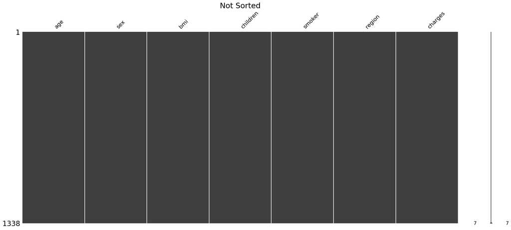

```python
#code taken from "DataVisualization.ipynb" given by Dr. Labiba
import matplotlib.pyplot as plt
import warnings
warnings.simplefilter('ignore', DeprecationWarning)
%matplotlib inline

import missingno as mn

mn.matrix(df)
plt.title("Not Sorted",fontsize=22)
```

**DATA VISUALIZATION**